# Topic models

Pablo Barbera

## Topic Modeling: LDA

While supervised learning is used when we know the categories we want to produce, unsupervised learning (including topic modeling) is used when we do not know the categories. In topic modeling, documents are not assumed to belong to one topic or category, but simultaneously belong to several topics. The topic distributions also vary over documents.

The workhorse function for the topic model is `LDA`, which stands for Latent Dirichlet Allocation, the technical name for this particular kind of model.

We will now use a dataset that contains the lead paragraph of around 5,000 articles about the economy published in the New York Times between 1980 and 2014. As before, we will preprocess the text using the standard set of techniques.

The number of topics in a topic model is somewhat arbitrary, so you need to play with the number of topics to see if you get anything more meaningful. We start here with 30 topics.

```r
library(topicmodels)
# reading data and preparing corpus object
nyt <- read.csv("../data/nytimes.csv", stringsAsFactors = FALSE)
library(quanteda)
library(dplyr)
# an example of how to process a dfm using dplyr:
nyt %>%
  corpus(text_field = "lead_paragraph") %>%
  tokens(remove_punct = TRUE, remove_numbers = TRUE) %>%
  dfm() %>%
  dfm_remove(stopwords("english")) %>%
  dfm_trim(min_docfreq = 2) -> cdfm

# estimate LDA with K topics
K <- 30
lda <- LDA(cdfm, k = K, method = "Gibbs",
                control = list(verbose=25L, seed = 123,
                               burnin = 100, iter = 500))
```

```
## K = 30; V = 11143; M = 5000
## Sampling 600 iterations!
## Iteration 25 ...
## Iteration 50 ...
## Iteration 75 ...
## Iteration 100 ...
## Iteration 125 ...
## Iteration 150 ...
## Iteration 175 ...
## Iteration 200 ...
## Iteration 225 ...
## Iteration 250 ...
## Iteration 275 ...
## Iteration 300 ...
## Iteration 325 ...
## Iteration 350 ...
## Iteration 375 ...
## Iteration 400 ...
## Iteration 425 ...
## Iteration 450 ...
## Iteration 475 ...
## Iteration 500 ...
## Iteration 525 ...
## Iteration 550 ...
## Iteration 575 ...
## Iteration 600 ...
## Gibbs sampling completed!
```

We can use `get_terms` to the top `n` terms from the topic model, and `get_topics` to predict the top `k` topic for each document. This will help us interpret the results of the model.

```r
terms <- get_terms(lda, 15)
terms[,1]
```

```
##  [1] "economic"   "government" "policy"     "can"        "public"
##  [6] "washington" "take"       "important"  "must"       "problems"
## [11] "current"    "power"      "issues"     "much"       "put"
```

```r
topics <- get_topics(lda, 1)
head(topics)
```

```
## text1 text2 text3 text4 text5 text6
##    27     5    15     3    25    21
```

Let’s take a closer look at some of these topics. To help us interpret the output, we can look at the words associated with each topic and take a random sample of documents highly associated with each topic.

```r
# Topic 2
paste(terms[,2], collapse=", ")
```

```
## [1] "tax, budget, spending, cuts, cut, taxes, fiscal, deficit, plan, deficits, military, congress, administration, federal, security"
```

```r
sample(nyt$lead_paragraph[topics==2], 1)
```

```
## [1] "Republican negotiators from Congress and the White House agreed today to seek $1.35 trillion in tax cuts over the next 11 years as part of a compromise budget, less than what President Bush proposed but still by far the largest tax reduction in the last 20 years. The negotiators remained dea…
```

```r
# Topic 3
paste(terms[,3], collapse=", ")
```

```
## [1] "jobs, unemployment, workers, labor, job, work, americans, employment, statistics, people, lost, added, benefits, force, millions"
```

```r
sample(nyt$lead_paragraph[topics==3], 1)
```

```
## [1] "SCHAUMBURG, Ill. -- After hemorrhaging jobs for months, the economy is finally starting to add them. Yet the unemployment rate is not really budging because of people like Regina Myles. Ms. Myles, 51, has been out of work for three years. After a grueling job search yielded 150 interviews bu…
```

```r
# Topic 4
paste(terms[,4], collapse=", ")
```

```
## [1] "percent, rate, quarter, first, year, economy, second, annual, growth, today, third, government, grew, productivity, expected"
```

```r
sample(nyt$lead_paragraph[topics==4], 1)
```

```
## [1] "Businesses and households went on a shopping spree this spring, causing warehouse stockpiles to shrink and setting the stage for faster economic growth during the rest of the year. The spending helped extend a solid if unspectacular expansion in the second quarter, when the economy grew at a…
```

```r
# Topic 14
paste(terms[,14], collapse=", ")
```

```
## [1] "economic, growth, economy, recovery, economists, said, recession, strong, recent, high, signs, still, forecast, next, evidence"
```

```r
sample(nyt$lead_paragraph[topics==14], 1)
```

```
## [1] "The Asian crisis may alarm Alan Greenspan and assorted other economists, but to the American people the economic outlook could not be rosier. That is what they tell the pollsters, who put consumer confidence at virtually the highest level in 30 years. More important, consumers act on that be…
```

You will that often some topics do not make much sense. They just capture the remaining cluster of words, and often correspond to stopwords. For example:

```r
# Topic 12
paste(terms[,12], collapse=", ")
```

```
## [1] "people, can, get, one, going, just, right, way, think, now, us, things, know, something, question"
```

```r
sample(nyt$lead_paragraph[topics==12], 1)
```

```
## [1] "ON a traditional farm, when winter comes and there's no need for planting, fertilizing or harvesting, it's time for infrastructure projects. Farmers fix their barns, build fences or dig wells -- important tasks that could be done in any season if there weren't more pressing jobs to do. If th…
```

```r
# Topic 19
paste(terms[,19], collapse=", ")
```

```
## [1] "two, years, time, even, now, first, weeks, less, likely, past, next, become, long, days, say"
```

```r
sample(nyt$lead_paragraph[topics==19], 1)
```

```
## [1] "To the Editor: Doris Lessing ends \"Language and the Lunatic Fringe\" (Op-Ed, June 26) with a warning that those in former Communist countries now search, \"perhaps not even knowing it,\" for another dogma. They need look no further than the United States. While lavishing praise upon ourselv…
```

```r
# Topic 25
paste(terms[,25], collapse=", ")
```

```
## [1] "market, stock, yesterday, investors, stocks, markets, average, interest, points, rates, day, bond, dow, treasury, trading"
```

```r
sample(nyt$lead_paragraph[topics==25], 1)
```

```
## [1] "The dollar ended lower against other leading currencies yesterday, hurt by growing pessimism that today's employment report for April would reveal more unsettling weakness in the American economy. Money brokers said there was some dollar buying early in the day. But later on, many traders re…
```

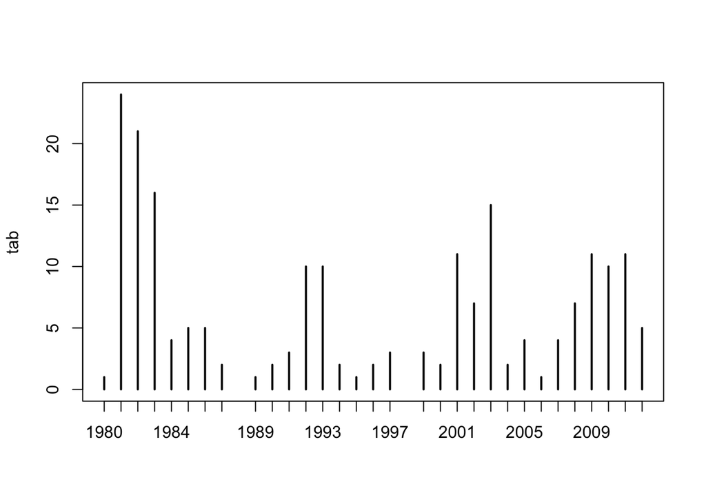

```r
# add predicted topic to dataset
nyt$pred_topic <- topics
nyt$year <- substr(nyt$datetime, 1, 4) # extract year
 # frequency table with articles about stock market, per year
tab <- table(nyt$year[nyt$pred_topic==2])
plot(tab)
```

But we can actually do better than this. LDA is a probabilistic model, which means that for each document, it actually computes a distribution over topics. In other words, each document is considered to be **about a mixture of topics**.

This information is included in the matrix `gamma` in the LDA object (`theta` in the notation we used for the slides). For example, article 1 is 21% about topic 27, 7% about topic 29, 4% about topic 2, and then less than 4% for each of the rest.

```r
round(lda@gamma[1,], 2)
```

```
##  [1] 0.02 0.04 0.04 0.02 0.03 0.02 0.02 0.02 0.02 0.03 0.02 0.02 0.04 0.02 0.02
## [16] 0.02 0.02 0.03 0.04 0.02 0.03 0.02 0.02 0.02 0.03 0.03 0.21 0.03 0.07 0.02
```

So we can actually take the information in the matrix and aggregate it to compute the average probability that an article each year is about a particular topic. Let’s now choose Topic 23, which appears to be related to the financial crisis.

```r
# Topic 23
paste(terms[,23], collapse=", ")
```

```
## [1] "financial, money, banks, crisis, credit, markets, bank, debt, nation's, system, loans, funds, supply, fund, savings"
```

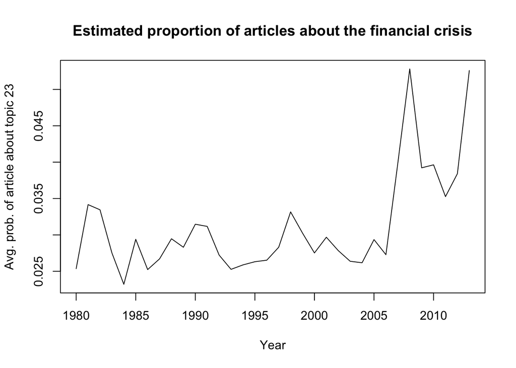

```r
# add probability to df
nyt$prob_topic <- lda@gamma[,23]
# now aggregate at the year level
agg <- aggregate(nyt$prob_topic, by=list(year=nyt$year), FUN=mean)
# and plot it
plot(agg$year, agg$x, type="l", xlab="Year", ylab="Avg. prob. of article about topic 23",
     main="Estimated proportion of articles about the financial crisis")
```